# Module 204

#### Hemi-module gene counts:

401 probesets in hemi-module A.  
38 probesets in hemi-module B.  
Note: While the mapping of probesets to genes is usually one-to-one, some genes are targeted by multiple probesets, some probesets target multiple genes, and some probesets do not target any genes (i.e., the region of the genome they match is no longer considered genic).

#### Contrast SVE:

Signed variance explained (SVE) provides an indication of how similar a set of fold changes are to a gene module’s weight vector. An SVE value of 0.3, for example, indicates that 30% of the variance explained by the entire module set is accounted for by the module in question. Shown here are the SVE values for this module across a compendium of fold changes (contrasts). Extreme SVE values (e.g., > 0.05) indicate that those contrasts specifically induce (orange dots) or specifically repress (blue dots) this module. Examining the experimental conditions being compared in such contrasts (see tables below the figure) may provide insight into the gene module’s function.

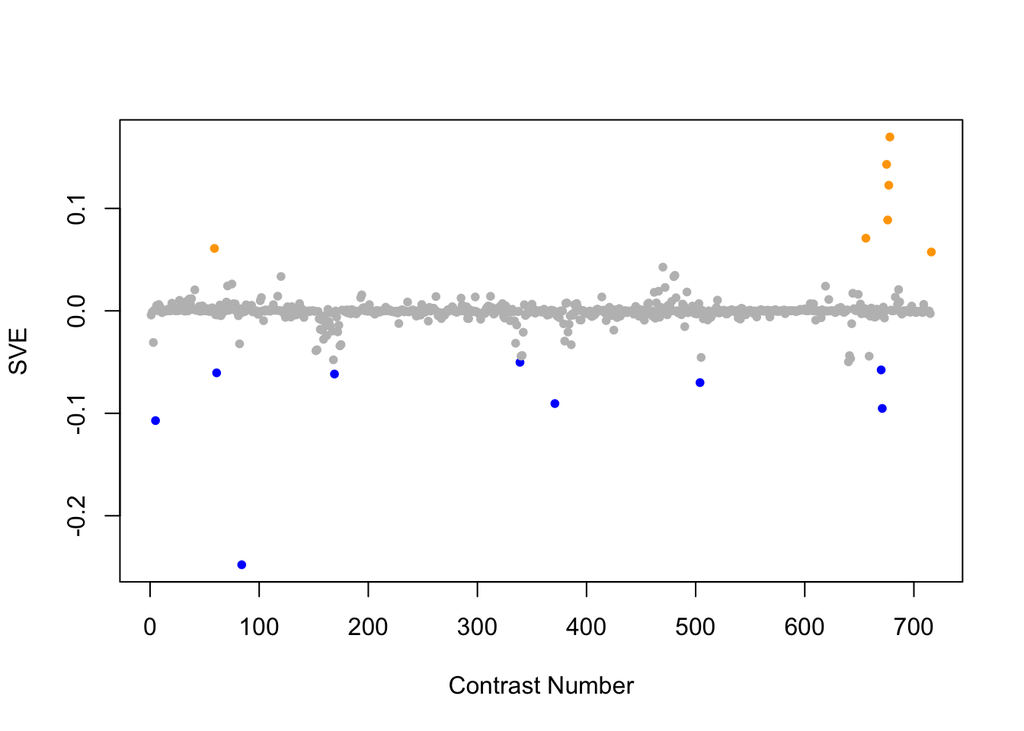

Positive SVE Contrasts:

|  | Contrast.Num | SVE | GEO.GSE | Cond.1 | Cond.2 | Mutation |
| --- | --- | --- | --- | --- | --- | --- |
| GSE13258.s1t1.vs.s0t1 | 678 | 0.17 | GSE13258 | zfp-1 mutant, biological rep 1 | wild-type, biological rep 1 | zfp-1 |
| GSE13258.s4t1.vs.s0t1 | 675 | 0.14 | GSE13258 | alg-1 mutant, biological rep 1 | wild-type, biological rep 1 | alg-1 |
| GSE13258.s2t1.vs.s0t1 | 677 | 0.12 | GSE13258 | rde-4 mutant, biological rep 1 | wild-type, biological rep 1 | rde-4 |
| GSE13258.s3t1.vs.s0t1 | 676 | 0.09 | GSE13258 | lin-35 mutant, biological rep 1 | wild-type, biological rep 1 | lin-35 |
| GSE16050.s1t1.vs.s0t1 | 656 | 0.07 | GSE16050 | MT_GFPp_rep1 | WT_GFPp_rep1 |  |
| GSE9301.s2t1.vs.s1t1 | 59 | 0.06 | GSE9301 | 3-day-old TJ1090 worms with skn-1 RNAi & oxidative stress (SO1) | 3-day-old TJ1090 worms with oxidative stress (O1) | skn-1 |
| GSE10787B.s1t1.vs.s0t1 | 716 | 0.06 | GSE10787 | Microwave (de_Pomerai_10_E5_C.Elegans) | Sham (de_Pomerai_1_S1_C.Elegans) |  |

Negative SVE Contrasts:

|  | Contrast.Num | SVE | GEO.GSE | Cond.1 | Cond.2 | Mutation |
| --- | --- | --- | --- | --- | --- | --- |
| GSE6547.s2t2.vs.s0t2 | 84 | -0.25 | GSE6547 | slr-2(ku297) worms at L1 stage, first replicate | N2 (wt) worms at L1 stage, first replicate | sir-2 |
| GSE9897B.s2t1.vs.s0t1 | 5 | -0.11 | GSE9897 | Complex I RNAi Mutant 2 | Wildtype (control for RNAi) | Y45G12B.1 |
| GSE15016.s1t1.vs.s0t1 | 671 | -0.10 | GSE15016 | young adult_24hr AgNPs exposure_rep1 | young adult_not exposured_rep1 |  |
| GSE35360C.s1t1.vs.s0t1 | 371 | -0.09 | GSE35360 | HFHQ 3d_0.2_rep1 | HFHQ 3d control_rep1 |  |
| GSE22660.s0t2.vs.s0t1 | 504 | -0.07 | GSE22660 | 1ug/ml DMSO control, biological rep 1 | 100ng/ml DMSO control, biological rep 1 |  |
| GSE47778.s5t3.vs.s3t3 | 169 | -0.06 | GSE47778 | xpa-1 10mJ/cm2; replicate 1 | daf-16; UV; replicate 1 | xpa-1 vs. daf-16 |
| GSE9301.s3t1.vs.s2t1 | 61 | -0.06 | GSE9301 | 3-day-old TJ1090 worms without any stress (C1) | 3-day-old TJ1090 worms with skn-1 RNAi & oxidative stress (SO1) |  |
| GSE15016.s2t1.vs.s0t1 | 670 | -0.06 | GSE15016 | young adult_24hr NP exposure_rep1 | young adult_not exposured_rep1 |  |
| GSE38997.s3t1.vs.s1t1 | 339 | -0.05 | GSE38997 | experiment 4 UVC- and EtBr-exposed samples at 3 h 4eu3 | experiment 4 control samples at 3 h 4c3 |  |

$~$

#### Contrast SVE, Up-Regulated Genes Only:

Calculating SVE for up-regulated and down-regulated genes separately may be more informative in many cases than projecting the up- and down- gene sets together. This is due to the fact that the weight distribution of many modules is highly skewed, indicating that only one of the hemi-modules may be biologically meaningful (i.e., a set of genes are strongly correlated by only a few genes (or none) are strongly anti-correlated to that set.)

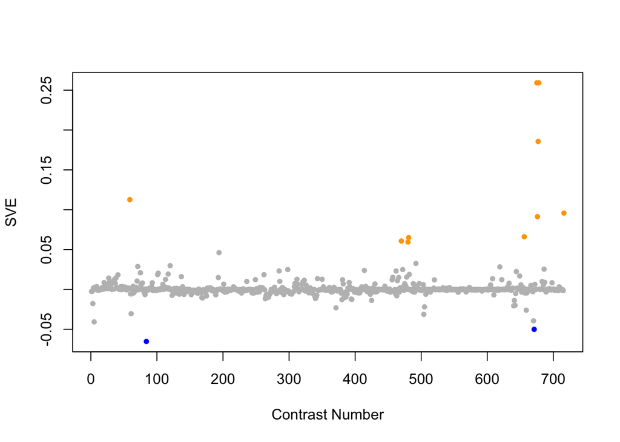

Positive SVE Contrasts:

|  | Contrast.Num | SVE | GEO.GSE | Cond.1 | Cond.2 | Mutation |
| --- | --- | --- | --- | --- | --- | --- |
| GSE13258.s1t1.vs.s0t1 | 678 | 0.26 | GSE13258 | zfp-1 mutant, biological rep 1 | wild-type, biological rep 1 | zfp-1 |
| GSE13258.s4t1.vs.s0t1 | 675 | 0.26 | GSE13258 | alg-1 mutant, biological rep 1 | wild-type, biological rep 1 | alg-1 |
| GSE13258.s2t1.vs.s0t1 | 677 | 0.19 | GSE13258 | rde-4 mutant, biological rep 1 | wild-type, biological rep 1 | rde-4 |
| GSE9301.s2t1.vs.s1t1 | 59 | 0.11 | GSE9301 | 3-day-old TJ1090 worms with skn-1 RNAi & oxidative stress (SO1) | 3-day-old TJ1090 worms with oxidative stress (O1) | skn-1 |
| GSE10787B.s1t1.vs.s0t1 | 716 | 0.10 | GSE10787 | Microwave (de_Pomerai_10_E5_C.Elegans) | Sham (de_Pomerai_1_S1_C.Elegans) |  |
| GSE13258.s3t1.vs.s0t1 | 676 | 0.09 | GSE13258 | lin-35 mutant, biological rep 1 | wild-type, biological rep 1 | lin-35 |
| GSE16050.s1t1.vs.s0t1 | 656 | 0.07 | GSE16050 | MT_GFPp_rep1 | WT_GFPp_rep1 |  |
| GSE23528A.s2t6.vs.s2t1 | 481 | 0.07 | GSE23528 | Adult at T22 in WC, time-series experiment 1 | Adult at T2 in WC, time-series experiment 1 |  |
| GSE23528A.s2t6.vs.s0t6 | 470 | 0.06 | GSE23528 | Adult at T22 in WC, time-series experiment 1 | Adult at T22, non-entrained control time-series experiment 4 |  |
| GSE23528A.s2t5.vs.s2t1 | 480 | 0.06 | GSE23528 | Adult at T18 in WC, time-series experiment 1 | Adult at T2 in WC, time-series experiment 1 |  |

Negative SVE Contrasts:

|  | Contrast.Num | SVE | GEO.GSE | Cond.1 | Cond.2 | Mutation |
| --- | --- | --- | --- | --- | --- | --- |
| GSE6547.s2t2.vs.s0t2 | 84 | -0.07 | GSE6547 | slr-2(ku297) worms at L1 stage, first replicate | N2 (wt) worms at L1 stage, first replicate | sir-2 |
| GSE15016.s1t1.vs.s0t1 | 671 | -0.05 | GSE15016 | young adult_24hr AgNPs exposure_rep1 | young adult_not exposured_rep1 |  |
| GSE9897B.s2t1.vs.s0t1 | 5 | -0.04 | GSE9897 | Complex I RNAi Mutant 2 | Wildtype (control for RNAi) | Y45G12B.1 |
| GSE15016.s2t1.vs.s0t1 | 670 | -0.04 | GSE15016 | young adult_24hr NP exposure_rep1 | young adult_not exposured_rep1 |  |
| GSE22660.s0t2.vs.s0t1 | 504 | -0.03 | GSE22660 | 1ug/ml DMSO control, biological rep 1 | 100ng/ml DMSO control, biological rep 1 |  |

$~$

#### Contrast SVE, Down-Regulated Genes Only:

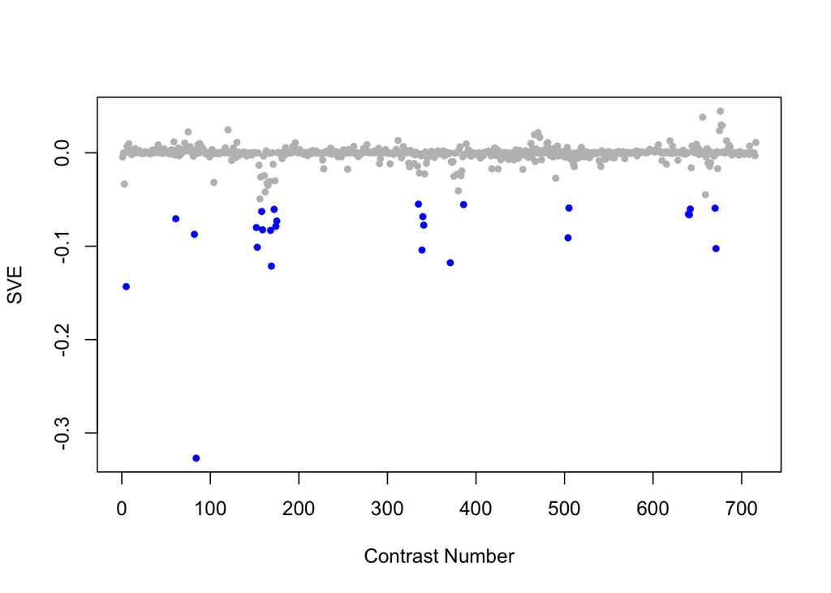

Positive SVE Contrasts:

|  | Contrast.Num | SVE | GEO.GSE | Cond.1 | Cond.2 | Mutation |
| --- | --- | --- | --- | --- | --- | --- |
| GSE13258.s3t1.vs.s0t1 | 676 | 0.04 | GSE13258 | lin-35 mutant, biological rep 1 | wild-type, biological rep 1 | lin-35 |
| GSE16050.s1t1.vs.s0t1 | 656 | 0.04 | GSE16050 | MT_GFPp_rep1 | WT_GFPp_rep1 |  |
| GSE13258.s2t1.vs.s0t1 | 677 | 0.03 | GSE13258 | rde-4 mutant, biological rep 1 | wild-type, biological rep 1 | rde-4 |
| GSE13258.s1t1.vs.s0t1 | 678 | 0.03 | GSE13258 | zfp-1 mutant, biological rep 1 | wild-type, biological rep 1 | zfp-1 |
| GSE54024.s3t1.vs.s4t1 | 120 | 0.02 | GSE54024 | nuo-6(qm200) young adults, biological rep 1 | isp-1(qm150) young adults, biological rep 1 |  |

Negative SVE Contrasts:

|  | Contrast.Num | SVE | GEO.GSE | Cond.1 | Cond.2 | Mutation |
| --- | --- | --- | --- | --- | --- | --- |
| GSE6547.s2t2.vs.s0t2 | 84 | -0.33 | GSE6547 | slr-2(ku297) worms at L1 stage, first replicate | N2 (wt) worms at L1 stage, first replicate | sir-2 |
| GSE9897B.s2t1.vs.s0t1 | 5 | -0.14 | GSE9897 | Complex I RNAi Mutant 2 | Wildtype (control for RNAi) | Y45G12B.1 |
| GSE47778.s5t3.vs.s3t3 | 169 | -0.12 | GSE47778 | xpa-1 10mJ/cm2; replicate 1 | daf-16; UV; replicate 1 | xpa-1 vs. daf-16 |
| GSE35360C.s1t1.vs.s0t1 | 371 | -0.12 | GSE35360 | HFHQ 3d_0.2_rep1 | HFHQ 3d control_rep1 |  |
| GSE38997.s3t1.vs.s1t1 | 339 | -0.10 | GSE38997 | experiment 4 UVC- and EtBr-exposed samples at 3 h 4eu3 | experiment 4 control samples at 3 h 4c3 |  |
| GSE15016.s1t1.vs.s0t1 | 671 | -0.10 | GSE15016 | young adult_24hr AgNPs exposure_rep1 | young adult_not exposured_rep1 |  |
| GSE47778.s5t1.vs.s3t1 | 153 | -0.10 | GSE47778 | xpa-1 0mJ/cm2; replicate 1 | daf-16; replicate 1 | xpa-1 vs. daf-16 |
| GSE22660.s0t2.vs.s0t1 | 504 | -0.09 | GSE22660 | 1ug/ml DMSO control, biological rep 1 | 100ng/ml DMSO control, biological rep 1 |  |
| GSE7354.s2t1.vs.s1t1 | 82 | -0.09 | GSE7354 | whole animal, nucleus accumbens: Extract1_le1 | whole animal, nucleus accumbens: Extract-Control_le1 |  |
| GSE47778.s1t3.vs.s3t3 | 168 | -0.08 | GSE47778 | N2; UV; replicate 1 | daf-16; UV; replicate 1 | daf-16 |
| GSE47778.s5t1.vs.s1t1 | 159 | -0.08 | GSE47778 | xpa-1 0mJ/cm2; replicate 1 | N2; replicate 1 | xpa-1 |
| GSE47778.s1t1.vs.s3t1 | 152 | -0.08 | GSE47778 | N2; replicate 1 | daf-16; replicate 1 | daf-16 |
| GSE47778.s5t3.vs.s4t3 | 174 | -0.08 | GSE47778 | xpa-1 10mJ/cm2; replicate 1 | daf-2;daf-16; UV; replicate 1 | xpa-1 vs. daf-2;daf-16 |
| GSE38997.s3t1.vs.s2t1 | 341 | -0.08 | GSE38997 | experiment 4 UVC- and EtBr-exposed samples at 3 h 4eu3 | experiment 4 EtBr-exposed samples at 3 h 4e3 |  |
| GSE47778.s5t3.vs.s1t3 | 175 | -0.07 | GSE47778 | xpa-1 10mJ/cm2; replicate 1 | N2; UV; replicate 1 | xpa-1 |
| GSE9301.s3t1.vs.s2t1 | 61 | -0.07 | GSE9301 | 3-day-old TJ1090 worms without any stress (C1) | 3-day-old TJ1090 worms with skn-1 RNAi & oxidative stress (SO1) |  |
| GSE38997.s4t1.vs.s1t1 | 340 | -0.07 | GSE38997 | experiment 4 UVC-exposed samples at 3 h 4u3 | experiment 4 control samples at 3 h 4c3 |  |
| GSE18132.s1t2.vs.s1t1 | 641 | -0.07 | GSE18132 | Ogt Fed L4, biological replicate 1 | Ogt starved L1, biological replicate 1 |  |
| GSE18132.s2t2.vs.s2t1 | 640 | -0.07 | GSE18132 | Oga Fed L4, biological replicate 1 | Oga starved L1, biological replicate 1 |  |
| GSE47778.s5t1.vs.s4t1 | 158 | -0.06 | GSE47778 | xpa-1 0mJ/cm2; replicate 1 | daf-2;daf-16; replicate 1 | xpa-1 vs. daf-2;daf-16 |
| GSE47778.s5t3.vs.s2t3 | 172 | -0.06 | GSE47778 | xpa-1 10mJ/cm2; replicate 1 | daf-2; UV; replicate 1 | xpa-1 vs. daf-2 |
| GSE18132.s0t2.vs.s0t1 | 642 | -0.06 | GSE18132 | WT Fed L4, biological rep1 | WT Starved L1, biological rep1 |  |
| GSE15016.s2t1.vs.s0t1 | 670 | -0.06 | GSE15016 | young adult_24hr NP exposure_rep1 | young adult_not exposured_rep1 |  |
| GSE22660.s1t2.vs.s1t1 | 505 | -0.06 | GSE22660 | 1ug/ml ivermectin exposure, biological rep 1 | 100ng/ml ivermectin exposure, biological rep 1 |  |
| GSE34026.s2t1.vs.s0t1 | 386 | -0.06 | GSE34026 | N2 exposed to E7946, biological rep1 | N2 exposed to OP50(E.coli), biological rep1 |  |
| GSE38997.s3t2.vs.s2t2 | 335 | -0.05 | GSE38997 | experiment 4 UVC- and EtBr-exposed samples at 24 h 4eu24 | experiment 4 EtBr-exposed samples at 24 h 4e24 |  |

$~$

$~$

#### GO Term Enrichment:

This analysis tests each hemi-module for enrichment of specific GO terms. Only gene-level annotations (e.g., as would be found on the gene’s page in Wormbase) are tested - the hierarchical structure of the GO ontology is not taken into account.

*Note: At least the top two most enriched terms from each GO domain (BP/MF/CC) are shown, even when not statistically significant.*

##### Enriched GO terms: Hemi-module A

| ID | GO.Term | GO Domain | Raw p-value | Adj p-value |
| --- | --- | --- | --- | --- |
| [GO_0002119](http://amigo.geneontology.org/amigo/term/GO:0002119) | nematode larval development | BP | 4.96e-07 | 9.25e-04 |
| [GO_0016310](http://amigo.geneontology.org/amigo/term/GO:0016310) | phosphorylation | BP | 5.08e-07 | 9.25e-04 |
| [GO_0010628](http://amigo.geneontology.org/amigo/term/GO:0010628) | positive regulation of gene expression | BP | 2.64e-06 | 3.21e-03 |
| [GO_0018107](http://amigo.geneontology.org/amigo/term/GO:0018107) | peptidyl-threonine phosphorylation | BP | 5.82e-06 | 5.12e-03 |
| [GO_0006468](http://amigo.geneontology.org/amigo/term/GO:0006468) | protein phosphorylation | BP | 7.03e-06 | 5.12e-03 |
| [GO_0018243](http://amigo.geneontology.org/amigo/term/GO:0018243) | protein O-linked glycosylation via threonine | BP | 1.78e-05 | 1.08e-02 |
| [GO_0018105](http://amigo.geneontology.org/amigo/term/GO:0018105) | peptidyl-serine phosphorylation | BP | 2.77e-05 | 1.44e-02 |
| [GO_0060562](http://amigo.geneontology.org/amigo/term/GO:0060562) | epithelial tube morphogenesis | BP | 5.23e-05 | 2.12e-02 |
| [GO_2000114](http://amigo.geneontology.org/amigo/term/GO:2000114) | regulation of establishment of cell polarity | BP | 5.23e-05 | 2.12e-02 |
| [GO_0040028](http://amigo.geneontology.org/amigo/term/GO:0040028) | regulation of vulval development | BP | 1.57e-04 | 5.19e-02 |
| [GO_0035556](http://amigo.geneontology.org/amigo/term/GO:0035556) | intracellular signal transduction | BP | 1.70e-04 | 5.19e-02 |
| [GO_1903358](http://amigo.geneontology.org/amigo/term/GO:1903358) | regulation of Golgi organization | BP | 1.71e-04 | 5.19e-02 |
| [GO_0050830](http://amigo.geneontology.org/amigo/term/GO:0050830) | defense response to Gram-positive bacterium | BP | 2.00e-04 | 5.59e-02 |
| [GO_0008340](http://amigo.geneontology.org/amigo/term/GO:0008340) | determination of adult lifespan | BP | 2.36e-04 | 6.14e-02 |
| [GO_0009792](http://amigo.geneontology.org/amigo/term/GO:0009792) | embryo development ending in birth or egg hatching | BP | 2.71e-04 | 6.58e-02 |
| [GO_0043547](http://amigo.geneontology.org/amigo/term/GO:0043547) | positive regulation of GTPase activity | BP | 3.44e-04 | 7.83e-02 |
| [GO_0016311](http://amigo.geneontology.org/amigo/term/GO:0016311) | dephosphorylation | BP | 3.84e-04 | 8.22e-02 |
| [GO_0000166](http://amigo.geneontology.org/amigo/term/GO:0000166) | nucleotide binding | MF | 2.29e-10 | 4.69e-07 |
| [GO_0004674](http://amigo.geneontology.org/amigo/term/GO:0004674) | protein serine/threonine kinase activity | MF | 4.81e-08 | 4.73e-05 |
| [GO_0016740](http://amigo.geneontology.org/amigo/term/GO:0016740) | transferase activity | MF | 6.94e-08 | 4.73e-05 |
| [GO_0005524](http://amigo.geneontology.org/amigo/term/GO:0005524) | ATP binding | MF | 1.39e-07 | 7.12e-05 |
| [GO_0016301](http://amigo.geneontology.org/amigo/term/GO:0016301) | kinase activity | MF | 3.36e-07 | 1.37e-04 |
| [GO_0005515](http://amigo.geneontology.org/amigo/term/GO:0005515) | protein binding | MF | 1.50e-05 | 5.10e-03 |
| [GO_0004672](http://amigo.geneontology.org/amigo/term/GO:0004672) | protein kinase activity | MF | 2.20e-05 | 6.43e-03 |
| [GO_0046872](http://amigo.geneontology.org/amigo/term/GO:0046872) | metal ion binding | MF | 3.38e-05 | 8.64e-03 |
| [GO_0004653](http://amigo.geneontology.org/amigo/term/GO:0004653) | polypeptide N-acetylgalactosaminyltransferase activity | MF | 1.71e-04 | 3.88e-02 |
| [GO_0008553](http://amigo.geneontology.org/amigo/term/GO:0008553) | proton-exporting ATPase activity, phosphorylative mechanism | MF | 3.35e-04 | 6.85e-02 |
| [GO_0004721](http://amigo.geneontology.org/amigo/term/GO:0004721) | phosphoprotein phosphatase activity | MF | 5.66e-04 | 9.79e-02 |
| [GO_0061575](http://amigo.geneontology.org/amigo/term/GO:0061575) | cyclin-dependent protein serine/threonine kinase activator activity | MF | 5.75e-04 | 9.79e-02 |
| [GO_0005737](http://amigo.geneontology.org/amigo/term/GO:0005737) | cytoplasm | CC | 5.51e-09 | 2.81e-06 |
| [GO_0016021](http://amigo.geneontology.org/amigo/term/GO:0016021) | integral component of membrane | CC | 6.05e-09 | 2.81e-06 |
| [GO_0005623](http://amigo.geneontology.org/amigo/term/GO:0005623) | cell | CC | 1.34e-06 | 3.84e-04 |
| [GO_0016020](http://amigo.geneontology.org/amigo/term/GO:0016020) | membrane | CC | 1.66e-06 | 3.84e-04 |
| [GO_0048471](http://amigo.geneontology.org/amigo/term/GO:0048471) | perinuclear region of cytoplasm | CC | 6.96e-06 | 1.29e-03 |
| [GO_0005739](http://amigo.geneontology.org/amigo/term/GO:0005739) | mitochondrion | CC | 2.22e-05 | 3.44e-03 |
| [GO_0005634](http://amigo.geneontology.org/amigo/term/GO:0005634) | nucleus | CC | 2.71e-05 | 3.59e-03 |
| [GO_0005743](http://amigo.geneontology.org/amigo/term/GO:0005743) | mitochondrial inner membrane | CC | 6.49e-05 | 7.52e-03 |
| [GO_0005759](http://amigo.geneontology.org/amigo/term/GO:0005759) | mitochondrial matrix | CC | 1.09e-04 | 1.13e-02 |
| [GO_0008024](http://amigo.geneontology.org/amigo/term/GO:0008024) | cyclin/CDK positive transcription elongation factor complex | CC | 1.71e-04 | 1.59e-02 |
| [GO_0005802](http://amigo.geneontology.org/amigo/term/GO:0005802) | trans-Golgi network | CC | 2.17e-04 | 1.83e-02 |
| [GO_0016471](http://amigo.geneontology.org/amigo/term/GO:0016471) | vacuolar proton-transporting V-type ATPase complex | CC | 5.75e-04 | 4.45e-02 |
| [GO_0005829](http://amigo.geneontology.org/amigo/term/GO:0005829) | cytosol | CC | 6.43e-04 | 4.59e-02 |
| [GO_0001891](http://amigo.geneontology.org/amigo/term/GO:0001891) | phagocytic cup | CC | 9.03e-04 | 5.90e-02 |
| [GO_0030424](http://amigo.geneontology.org/amigo/term/GO:0030424) | axon | CC | 9.53e-04 | 5.90e-02 |
| [GO_0016529](http://amigo.geneontology.org/amigo/term/GO:0016529) | sarcoplasmic reticulum | CC | 1.05e-03 | 6.12e-02 |

##### Enriched GO terms: Hemi-module B

| ID | GO.Term | GO Domain | Raw p-value | Adj p-value |
| --- | --- | --- | --- | --- |
| [GO_0000381](http://amigo.geneontology.org/amigo/term/GO:0000381) | regulation of alternative mRNA splicing, via spliceosome | BP | 2.04e-03 | 1.00e+00 |
| [GO_0002191](http://amigo.geneontology.org/amigo/term/GO:0002191) | cap-dependent translational initiation | BP | 2.41e-03 | 1.00e+00 |
| [GO_0003723](http://amigo.geneontology.org/amigo/term/GO:0003723) | RNA binding | MF | 3.14e-04 | 6.41e-01 |
| [GO_0004551](http://amigo.geneontology.org/amigo/term/GO:0004551) | nucleotide diphosphatase activity | MF | 2.41e-03 | 9.85e-01 |
| [GO_0000111](http://amigo.geneontology.org/amigo/term/GO:0000111) | nucleotide-excision repair factor 2 complex | CC | 2.41e-03 | 8.08e-01 |
| [GO_0071942](http://amigo.geneontology.org/amigo/term/GO:0071942) | XPC complex | CC | 2.41e-03 | 8.08e-01 |

$~$

$~$

#### Tissue Enrichment:

This analysis tests each hemi-module for enrichment of genes associated with anatomy terms. Negative enrichment scores indicate fewer hemi-module genes than expected by random chance were associated with the anatomy term in question.

##### Enriched tissues: Hemi-module A

| ID | Anatomy.Term | Definition | Raw p-value | Adj p-value |
| --- | --- | --- | --- | --- |
| [WBbt_0005813](https://wormbase.org/species/all/anatomy_term/WBbt:0005813) | body wall musculature | Longitudinal bands of muscle cells surrounding animal body, with one band running in each quadrant of the body, regulated contraction and relaxation of these muscles cause locomotion. | 8.80e-11 | 2.14e-07 |
| [WBbt_0003681](https://wormbase.org/species/all/anatomy_term/WBbt:0003681) | pharynx | the feeding organ, a neuro-muscular pump in the head of the animal, used to ingest food, bacteria suspended in liquid, filter them out, grind them up and transport posteriorly into the instestine. | 1.71e-08 | 2.08e-05 |
| [WBbt_0005319](https://wormbase.org/species/all/anatomy_term/WBbt:0005319) | spermatheca | an accordion-like tube that contains sperm and is the site of oocyte fertilization. | 7.66e-08 | 6.21e-05 |
| [WBbt_0006748](https://wormbase.org/species/all/anatomy_term/WBbt:0006748) | vulva | female genital. | 6.38e-07 | 3.88e-04 |
| [WBbt_0005772](https://wormbase.org/species/all/anatomy_term/WBbt:0005772) | intestine | A chain of very large cuboidal cells forming a wide central lumen in which food arrives from the posterior pharynx, is digested, and from which waste products proceed to the rectum. Intestinal rings f… | 1.02e-06 | 4.97e-04 |
| [WBbt_0004017](https://wormbase.org/species/all/anatomy_term/WBbt:0004017) | Cell | a cellular object that consists of subcellular components, expresses genes or functions. | 1.41e-06 | 5.71e-04 |
| [WBbt_0005828](https://wormbase.org/species/all/anatomy_term/WBbt:0005828) | gonadal sheath cell | five pairs of thin gonadal sheath cells form a single layer covering the germ line component of each arm, each pair occupying a stereotyped position along the gonad proximal-distal axis. | 4.63e-06 | 1.54e-03 |
| [WBbt_0005821](https://wormbase.org/species/all/anatomy_term/WBbt:0005821) | vulval muscle | muscle associated with hermaphrodite vulva. | 5.07e-06 | 1.54e-03 |
| [WBbt_0005733](https://wormbase.org/species/all/anatomy_term/WBbt:0005733) | hypodermis | Epidermal layer. | 1.95e-05 | 5.27e-03 |
| [WBbt_0005735](https://wormbase.org/species/all/anatomy_term/WBbt:0005735) | nervous system | Complement of nervous tissue (neurones, nerves, receptors and support cells) serving to detect, relay and coordinate information about an animal’s internal and external environments and to initiate an… | 9.20e-05 | 2.24e-02 |
| [WBbt_0005747](https://wormbase.org/species/all/anatomy_term/WBbt:0005747) | reproductive system |  | 1.32e-04 | 2.92e-02 |
| [WBbt_0005753](https://wormbase.org/species/all/anatomy_term/WBbt:0005753) | seam cell | a group of hypodermal cells that lie along the apical midline of the hypodermis, at the extreme left and right sides between nose and tail | 2.33e-04 | 4.72e-02 |
| [WBbt_0004522](https://wormbase.org/species/all/anatomy_term/WBbt:0004522) | anchor cell | anchor cell, induces vulva, part of hermaphrodite gonad. | 4.38e-04 | 8.20e-02 |
| [WBbt_0005300](https://wormbase.org/species/all/anatomy_term/WBbt:0005300) | ventral cord neuron | neuron with cell body associated with the ventral nerve cord. | 5.54e-04 | 9.63e-02 |

##### Enriched tissues: Hemi-module B

No significant annotations.

$~$

$~$

#### HOMER promoter motif enrichment:

This analysis tests each hemi-module for enrichment of 108 known *C. elegans* transcription factor binding site motifs (see [108 CE motifs](https://katiepod.github.io//all.worm.motifs.html)) using the HOMER (Hypergeometric Optimization of Motif EnRichment) software (see [PMID:20513432](https://pubmed.ncbi.nlm.nih.gov/20513432)). HOMER was run using default parameters on sequences 1 kb upstream of the transcription start site.

##### Motif enrichment: Hemi-module A

Total target sequences = 345  
Total background sequences = 37004  
* - possible false positive

Rank

Motif

P-value

log P-pvalue

% of Targets

% of Background

STD(Bg STD)

Best Match/Details

Motif File

1

[figure not shown]

1e-13

-3.189e+01

52.75%

32.63%

297.1bp (366.5bp)

ceh-38/MA1699.1/Jaspar(0.838)  
[More Information](https://katiepod.github.io/HomerResults/m204_a_hemi_genes.txt.out.1kb/homerResults/motif1.info.html) | [Similar Motifs Found](https://katiepod.github.io/HomerResults/m204_a_hemi_genes.txt.out.1kb/homerResults/motif1.similar.html)

[motif file (matrix)](https://katiepod.github.io/HomerResults/m204_a_hemi_genes.txt.out.1kb/homerResults/motif1.motif)

2

[figure not shown]

1e-12

-2.882e+01

8.12%

1.39%

300.2bp (350.4bp)

efl-1/MA0541.1/Jaspar(0.651)  
[More Information](https://katiepod.github.io/HomerResults/m204_a_hemi_genes.txt.out.1kb/homerResults/motif2.info.html) | [Similar Motifs Found](https://katiepod.github.io/HomerResults/m204_a_hemi_genes.txt.out.1kb/homerResults/motif2.similar.html)

[motif file (matrix)](https://katiepod.github.io/HomerResults/m204_a_hemi_genes.txt.out.1kb/homerResults/motif2.motif)

3 *

[figure not shown]

1e-11

-2.665e+01

20.29%

8.22%

271.4bp (341.4bp)

blmp-1/MA0537.1/Jaspar(0.768)  
[More Information](https://katiepod.github.io/HomerResults/m204_a_hemi_genes.txt.out.1kb/homerResults/motif3.info.html) | [Similar Motifs Found](https://katiepod.github.io/HomerResults/m204_a_hemi_genes.txt.out.1kb/homerResults/motif3.similar.html)

[motif file (matrix)](https://katiepod.github.io/HomerResults/m204_a_hemi_genes.txt.out.1kb/homerResults/motif3.motif)

4 *

[figure not shown]

1e-11

-2.627e+01

4.64%

0.40%

303.3bp (328.9bp)

MF0010.1_Homeobox_class/Jaspar(0.561)  
[More Information](https://katiepod.github.io/HomerResults/m204_a_hemi_genes.txt.out.1kb/homerResults/motif4.info.html) | [Similar Motifs Found](https://katiepod.github.io/HomerResults/m204_a_hemi_genes.txt.out.1kb/homerResults/motif4.similar.html)

[motif file (matrix)](https://katiepod.github.io/HomerResults/m204_a_hemi_genes.txt.out.1kb/homerResults/motif4.motif)

5 *

[figure not shown]

1e-11

-2.614e+01

44.06%

26.74%

290.7bp (361.3bp)

blmp-1/MA0537.1/Jaspar(0.570)  
[More Information](https://katiepod.github.io/HomerResults/m204_a_hemi_genes.txt.out.1kb/homerResults/motif5.info.html) | [Similar Motifs Found](https://katiepod.github.io/HomerResults/m204_a_hemi_genes.txt.out.1kb/homerResults/motif5.similar.html)

[motif file (matrix)](https://katiepod.github.io/HomerResults/m204_a_hemi_genes.txt.out.1kb/homerResults/motif5.motif)

6 *

[figure not shown]

1e-10

-2.507e+01

7.54%

1.41%

202.3bp (327.5bp)

PHA-4(Forkhead)/cElegans-Embryos-PHA4-ChIP-Seq(modEncode)/Homer(0.642)  
[More Information](https://katiepod.github.io/HomerResults/m204_a_hemi_genes.txt.out.1kb/homerResults/motif6.info.html) | [Similar Motifs Found](https://katiepod.github.io/HomerResults/m204_a_hemi_genes.txt.out.1kb/homerResults/motif6.similar.html)

[motif file (matrix)](https://katiepod.github.io/HomerResults/m204_a_hemi_genes.txt.out.1kb/homerResults/motif6.motif)

7 *

[figure not shown]

1e-10

-2.385e+01

6.38%

1.04%

290.8bp (321.3bp)

EGL-5(Homeobox)/cElegans-L3-EGL5-ChIP-Seq(modEncode)/Homer(0.607)  
[More Information](https://katiepod.github.io/HomerResults/m204_a_hemi_genes.txt.out.1kb/homerResults/motif7.info.html) | [Similar Motifs Found](https://katiepod.github.io/HomerResults/m204_a_hemi_genes.txt.out.1kb/homerResults/motif7.similar.html)

[motif file (matrix)](https://katiepod.github.io/HomerResults/m204_a_hemi_genes.txt.out.1kb/homerResults/motif7.motif)

8 *

[figure not shown]

1e-10

-2.376e+01

9.86%

2.55%

249.0bp (352.3bp)

MF0009.1_TRP(MYB)_class/Jaspar(0.583)  
[More Information](https://katiepod.github.io/HomerResults/m204_a_hemi_genes.txt.out.1kb/homerResults/motif8.info.html) | [Similar Motifs Found](https://katiepod.github.io/HomerResults/m204_a_hemi_genes.txt.out.1kb/homerResults/motif8.similar.html)

[motif file (matrix)](https://katiepod.github.io/HomerResults/m204_a_hemi_genes.txt.out.1kb/homerResults/motif8.motif)

9 *

[figure not shown]

1e-10

-2.344e+01

2.90%

0.12%

319.4bp (280.5bp)

LIN-39(Homeobox)/cElegans.L3-LIN39-ChIP-Seq(modEncode)/Homer(0.621)  
[More Information](https://katiepod.github.io/HomerResults/m204_a_hemi_genes.txt.out.1kb/homerResults/motif9.info.html) | [Similar Motifs Found](https://katiepod.github.io/HomerResults/m204_a_hemi_genes.txt.out.1kb/homerResults/motif9.similar.html)

[motif file (matrix)](https://katiepod.github.io/HomerResults/m204_a_hemi_genes.txt.out.1kb/homerResults/motif9.motif)

10 *

[figure not shown]

1e-10

-2.314e+01

28.41%

14.81%

279.5bp (350.9bp)

ceh-38/MA1699.1/Jaspar(0.632)  
[More Information](https://katiepod.github.io/HomerResults/m204_a_hemi_genes.txt.out.1kb/homerResults/motif10.info.html) | [Similar Motifs Found](https://katiepod.github.io/HomerResults/m204_a_hemi_genes.txt.out.1kb/homerResults/motif10.similar.html)

[motif file (matrix)](https://katiepod.github.io/HomerResults/m204_a_hemi_genes.txt.out.1kb/homerResults/motif10.motif)

11 *

[figure not shown]

1e-9

-2.229e+01

6.09%

1.02%

259.2bp (330.8bp)

MF0005.1_Forkhead_class/Jaspar(0.567)  
[More Information](https://katiepod.github.io/HomerResults/m204_a_hemi_genes.txt.out.1kb/homerResults/motif11.info.html) | [Similar Motifs Found](https://katiepod.github.io/HomerResults/m204_a_hemi_genes.txt.out.1kb/homerResults/motif11.similar.html)

[motif file (matrix)](https://katiepod.github.io/HomerResults/m204_a_hemi_genes.txt.out.1kb/homerResults/motif11.motif)

12 *

[figure not shown]

1e-9

-2.224e+01

7.54%

1.61%

250.9bp (326.7bp)

PHA-4(Forkhead)/cElegans-Embryos-PHA4-ChIP-Seq(modEncode)/Homer(0.727)  
[More Information](https://katiepod.github.io/HomerResults/m204_a_hemi_genes.txt.out.1kb/homerResults/motif12.info.html) | [Similar Motifs Found](https://katiepod.github.io/HomerResults/m204_a_hemi_genes.txt.out.1kb/homerResults/motif12.similar.html)

[motif file (matrix)](https://katiepod.github.io/HomerResults/m204_a_hemi_genes.txt.out.1kb/homerResults/motif12.motif)

13 *

[figure not shown]

1e-9

-2.217e+01

4.93%

0.63%

252.8bp (422.2bp)

MF0001.1_ETS_class/Jaspar(0.544)  
[More Information](https://katiepod.github.io/HomerResults/m204_a_hemi_genes.txt.out.1kb/homerResults/motif13.info.html) | [Similar Motifs Found](https://katiepod.github.io/HomerResults/m204_a_hemi_genes.txt.out.1kb/homerResults/motif13.similar.html)

[motif file (matrix)](https://katiepod.github.io/HomerResults/m204_a_hemi_genes.txt.out.1kb/homerResults/motif13.motif)

14 *

[figure not shown]

1e-9

-2.196e+01

12.46%

4.15%

276.9bp (330.2bp)

fkh-9/MA1440.1/Jaspar(0.651)  
[More Information](https://katiepod.github.io/HomerResults/m204_a_hemi_genes.txt.out.1kb/homerResults/motif14.info.html) | [Similar Motifs Found](https://katiepod.github.io/HomerResults/m204_a_hemi_genes.txt.out.1kb/homerResults/motif14.similar.html)

[motif file (matrix)](https://katiepod.github.io/HomerResults/m204_a_hemi_genes.txt.out.1kb/homerResults/motif14.motif)

15 *

[figure not shown]

1e-9

-2.162e+01

6.96%

1.41%

281.5bp (376.1bp)

daf-12/MA0538.1/Jaspar(0.632)  
[More Information](https://katiepod.github.io/HomerResults/m204_a_hemi_genes.txt.out.1kb/homerResults/motif15.info.html) | [Similar Motifs Found](https://katiepod.github.io/HomerResults/m204_a_hemi_genes.txt.out.1kb/homerResults/motif15.similar.html)

[motif file (matrix)](https://katiepod.github.io/HomerResults/m204_a_hemi_genes.txt.out.1kb/homerResults/motif15.motif)

16 *

[figure not shown]

1e-9

-2.121e+01

4.35%

0.50%

259.0bp (343.2bp)

EGL-5(Homeobox)/cElegans-L3-EGL5-ChIP-Seq(modEncode)/Homer(0.719)  
[More Information](https://katiepod.github.io/HomerResults/m204_a_hemi_genes.txt.out.1kb/homerResults/motif16.info.html) | [Similar Motifs Found](https://katiepod.github.io/HomerResults/m204_a_hemi_genes.txt.out.1kb/homerResults/motif16.similar.html)

[motif file (matrix)](https://katiepod.github.io/HomerResults/m204_a_hemi_genes.txt.out.1kb/homerResults/motif16.motif)

17 *

[figure not shown]

1e-9

-2.103e+01

26.38%

13.83%

295.9bp (382.2bp)

cebp-1/MA1444.1/Jaspar(0.737)  
[More Information](https://katiepod.github.io/HomerResults/m204_a_hemi_genes.txt.out.1kb/homerResults/motif17.info.html) | [Similar Motifs Found](https://katiepod.github.io/HomerResults/m204_a_hemi_genes.txt.out.1kb/homerResults/motif17.similar.html)

[motif file (matrix)](https://katiepod.github.io/HomerResults/m204_a_hemi_genes.txt.out.1kb/homerResults/motif17.motif)

18 *

[figure not shown]

1e-8

-2.054e+01

7.54%

1.75%

245.0bp (388.6bp)

LIN-15B(Zf)/cElegans-L3-LIN15B-ChIP-Seq(modEncode)/Homer(0.624)  
[More Information](https://katiepod.github.io/HomerResults/m204_a_hemi_genes.txt.out.1kb/homerResults/motif18.info.html) | [Similar Motifs Found](https://katiepod.github.io/HomerResults/m204_a_hemi_genes.txt.out.1kb/homerResults/motif18.similar.html)

[motif file (matrix)](https://katiepod.github.io/HomerResults/m204_a_hemi_genes.txt.out.1kb/homerResults/motif18.motif)

19 *

[figure not shown]

1e-8

-2.017e+01

7.25%

1.65%

272.8bp (376.2bp)

MF0001.1_ETS_class/Jaspar(0.658)  
[More Information](https://katiepod.github.io/HomerResults/m204_a_hemi_genes.txt.out.1kb/homerResults/motif19.info.html) | [Similar Motifs Found](https://katiepod.github.io/HomerResults/m204_a_hemi_genes.txt.out.1kb/homerResults/motif19.similar.html)

[motif file (matrix)](https://katiepod.github.io/HomerResults/m204_a_hemi_genes.txt.out.1kb/homerResults/motif19.motif)

20 *

[figure not shown]

1e-8

-2.014e+01

15.36%

6.22%

278.8bp (327.1bp)

cebp-1/MA1444.1/Jaspar(0.696)  
[More Information](https://katiepod.github.io/HomerResults/m204_a_hemi_genes.txt.out.1kb/homerResults/motif20.info.html) | [Similar Motifs Found](https://katiepod.github.io/HomerResults/m204_a_hemi_genes.txt.out.1kb/homerResults/motif20.similar.html)

[motif file (matrix)](https://katiepod.github.io/HomerResults/m204_a_hemi_genes.txt.out.1kb/homerResults/motif20.motif)

21 *

[figure not shown]

1e-8

-2.012e+01

20.58%

9.77%

296.4bp (413.6bp)

efl-1/MA0541.1/Jaspar(0.496)  
[More Information](https://katiepod.github.io/HomerResults/m204_a_hemi_genes.txt.out.1kb/homerResults/motif21.info.html) | [Similar Motifs Found](https://katiepod.github.io/HomerResults/m204_a_hemi_genes.txt.out.1kb/homerResults/motif21.similar.html)

[motif file (matrix)](https://katiepod.github.io/HomerResults/m204_a_hemi_genes.txt.out.1kb/homerResults/motif21.motif)

22 *

[figure not shown]

1e-8

-1.959e+01

10.14%

3.17%

277.7bp (359.8bp)

SD0001.1_at_AC_acceptor/Jaspar(0.578)  
[More Information](https://katiepod.github.io/HomerResults/m204_a_hemi_genes.txt.out.1kb/homerResults/motif22.info.html) | [Similar Motifs Found](https://katiepod.github.io/HomerResults/m204_a_hemi_genes.txt.out.1kb/homerResults/motif22.similar.html)

[motif file (matrix)](https://katiepod.github.io/HomerResults/m204_a_hemi_genes.txt.out.1kb/homerResults/motif22.motif)

23 *

[figure not shown]

1e-8

-1.893e+01

5.22%

0.90%

281.3bp (359.5bp)

POL009.1_DCE_S_II/Jaspar(0.609)  
[More Information](https://katiepod.github.io/HomerResults/m204_a_hemi_genes.txt.out.1kb/homerResults/motif23.info.html) | [Similar Motifs Found](https://katiepod.github.io/HomerResults/m204_a_hemi_genes.txt.out.1kb/homerResults/motif23.similar.html)

[motif file (matrix)](https://katiepod.github.io/HomerResults/m204_a_hemi_genes.txt.out.1kb/homerResults/motif23.motif)

24 *

[figure not shown]

1e-7

-1.744e+01

15.36%

6.75%

272.3bp (346.4bp)

SD0003.1_at_AC_acceptor/Jaspar(0.516)  
[More Information](https://katiepod.github.io/HomerResults/m204_a_hemi_genes.txt.out.1kb/homerResults/motif24.info.html) | [Similar Motifs Found](https://katiepod.github.io/HomerResults/m204_a_hemi_genes.txt.out.1kb/homerResults/motif24.similar.html)

[motif file (matrix)](https://katiepod.github.io/HomerResults/m204_a_hemi_genes.txt.out.1kb/homerResults/motif24.motif)

25 *

[figure not shown]

1e-7

-1.619e+01

5.22%

1.08%

251.7bp (345.2bp)

DPL-1(E2F)/cElegans-Adult-ChIP-Seq(modEncode)/Homer(0.666)  
[More Information](https://katiepod.github.io/HomerResults/m204_a_hemi_genes.txt.out.1kb/homerResults/motif25.info.html) | [Similar Motifs Found](https://katiepod.github.io/HomerResults/m204_a_hemi_genes.txt.out.1kb/homerResults/motif25.similar.html)

[motif file (matrix)](https://katiepod.github.io/HomerResults/m204_a_hemi_genes.txt.out.1kb/homerResults/motif25.motif)

26 *

[figure not shown]

1e-6

-1.541e+01

9.57%

3.43%

226.8bp (383.5bp)

EFL-1(E2F)/cElegans-L1-EFL1-ChIP-Seq(modEncode)/Homer(0.770)  
[More Information](https://katiepod.github.io/HomerResults/m204_a_hemi_genes.txt.out.1kb/homerResults/motif26.info.html) | [Similar Motifs Found](https://katiepod.github.io/HomerResults/m204_a_hemi_genes.txt.out.1kb/homerResults/motif26.similar.html)

[motif file (matrix)](https://katiepod.github.io/HomerResults/m204_a_hemi_genes.txt.out.1kb/homerResults/motif26.motif)

27 *

[figure not shown]

1e-6

-1.477e+01

4.93%

1.07%

287.2bp (365.5bp)

EGL-5(Homeobox)/cElegans-L3-EGL5-ChIP-Seq(modEncode)/Homer(0.633)  
[More Information](https://katiepod.github.io/HomerResults/m204_a_hemi_genes.txt.out.1kb/homerResults/motif27.info.html) | [Similar Motifs Found](https://katiepod.github.io/HomerResults/m204_a_hemi_genes.txt.out.1kb/homerResults/motif27.similar.html)

[motif file (matrix)](https://katiepod.github.io/HomerResults/m204_a_hemi_genes.txt.out.1kb/homerResults/motif27.motif)

28 *

[figure not shown]

1e-6

-1.440e+01

12.46%

5.45%

291.8bp (375.9bp)

PL0007.1_mxl-3/Jaspar(0.565)  
[More Information](https://katiepod.github.io/HomerResults/m204_a_hemi_genes.txt.out.1kb/homerResults/motif28.info.html) | [Similar Motifs Found](https://katiepod.github.io/HomerResults/m204_a_hemi_genes.txt.out.1kb/homerResults/motif28.similar.html)

[motif file (matrix)](https://katiepod.github.io/HomerResults/m204_a_hemi_genes.txt.out.1kb/homerResults/motif28.motif)

29 *

[figure not shown]

1e-6

-1.432e+01

11.88%

5.08%

304.9bp (327.1bp)

POL009.1_DCE_S_II/Jaspar(0.551)  
[More Information](https://katiepod.github.io/HomerResults/m204_a_hemi_genes.txt.out.1kb/homerResults/motif29.info.html) | [Similar Motifs Found](https://katiepod.github.io/HomerResults/m204_a_hemi_genes.txt.out.1kb/homerResults/motif29.similar.html)

[motif file (matrix)](https://katiepod.github.io/HomerResults/m204_a_hemi_genes.txt.out.1kb/homerResults/motif29.motif)

30 *

[figure not shown]

1e-5

-1.366e+01

3.19%

0.46%

221.0bp (351.8bp)

vab-7/MA0927.1/Jaspar(0.677)  
[More Information](https://katiepod.github.io/HomerResults/m204_a_hemi_genes.txt.out.1kb/homerResults/motif30.info.html) | [Similar Motifs Found](https://katiepod.github.io/HomerResults/m204_a_hemi_genes.txt.out.1kb/homerResults/motif30.similar.html)

[motif file (matrix)](https://katiepod.github.io/HomerResults/m204_a_hemi_genes.txt.out.1kb/homerResults/motif30.motif)

31 *

[figure not shown]

1e-5

-1.348e+01

61.16%

48.38%

286.1bp (386.0bp)

ceh-48/MA0921.1/Jaspar(0.595)  
[More Information](https://katiepod.github.io/HomerResults/m204_a_hemi_genes.txt.out.1kb/homerResults/motif31.info.html) | [Similar Motifs Found](https://katiepod.github.io/HomerResults/m204_a_hemi_genes.txt.out.1kb/homerResults/motif31.similar.html)

[motif file (matrix)](https://katiepod.github.io/HomerResults/m204_a_hemi_genes.txt.out.1kb/homerResults/motif31.motif)

32 *

[figure not shown]

1e-5

-1.326e+01

6.96%

2.24%

296.3bp (346.4bp)

che-1/MA0260.1/Jaspar(0.613)  
[More Information](https://katiepod.github.io/HomerResults/m204_a_hemi_genes.txt.out.1kb/homerResults/motif32.info.html) | [Similar Motifs Found](https://katiepod.github.io/HomerResults/m204_a_hemi_genes.txt.out.1kb/homerResults/motif32.similar.html)

[motif file (matrix)](https://katiepod.github.io/HomerResults/m204_a_hemi_genes.txt.out.1kb/homerResults/motif32.motif)

33 *

[figure not shown]

1e-5

-1.237e+01

11.01%

4.91%

265.9bp (357.5bp)

fos-1/MA1448.1/Jaspar(0.746)  
[More Information](https://katiepod.github.io/HomerResults/m204_a_hemi_genes.txt.out.1kb/homerResults/motif33.info.html) | [Similar Motifs Found](https://katiepod.github.io/HomerResults/m204_a_hemi_genes.txt.out.1kb/homerResults/motif33.similar.html)

[motif file (matrix)](https://katiepod.github.io/HomerResults/m204_a_hemi_genes.txt.out.1kb/homerResults/motif33.motif)

34 *

[figure not shown]

1e-5

-1.191e+01

7.25%

2.61%

230.5bp (349.1bp)

skn-1/MA0547.1/Jaspar(0.631)  
[More Information](https://katiepod.github.io/HomerResults/m204_a_hemi_genes.txt.out.1kb/homerResults/motif34.info.html) | [Similar Motifs Found](https://katiepod.github.io/HomerResults/m204_a_hemi_genes.txt.out.1kb/homerResults/motif34.similar.html)

[motif file (matrix)](https://katiepod.github.io/HomerResults/m204_a_hemi_genes.txt.out.1kb/homerResults/motif34.motif)

35 *

[figure not shown]

1e-4

-1.078e+01

2.03%

0.23%

179.8bp (283.2bp)

unc-30/MA1443.1/Jaspar(0.674)  
[More Information](https://katiepod.github.io/HomerResults/m204_a_hemi_genes.txt.out.1kb/homerResults/motif35.info.html) | [Similar Motifs Found](https://katiepod.github.io/HomerResults/m204_a_hemi_genes.txt.out.1kb/homerResults/motif35.similar.html)

[motif file (matrix)](https://katiepod.github.io/HomerResults/m204_a_hemi_genes.txt.out.1kb/homerResults/motif35.motif)

36 *

[figure not shown]

1e-3

-8.684e+00

20.00%

12.95%

290.1bp (371.8bp)

POL003.1_GC-box/Jaspar(0.732)  
[More Information](https://katiepod.github.io/HomerResults/m204_a_hemi_genes.txt.out.1kb/homerResults/motif36.info.html) | [Similar Motifs Found](https://katiepod.github.io/HomerResults/m204_a_hemi_genes.txt.out.1kb/homerResults/motif36.similar.html)

[motif file (matrix)](https://katiepod.github.io/HomerResults/m204_a_hemi_genes.txt.out.1kb/homerResults/motif36.motif)

##### Motif enrichment: Hemi-module B

Total target sequences = 31  
Total background sequences = 36773  
* - possible false positive

Rank

Motif

P-value

log P-pvalue

% of Targets

% of Background

STD(Bg STD)

Best Match/Details

Motif File

1 *

[figure not shown]

1e-9

-2.272e+01

12.90%

0.02%

270.1bp (167.4bp)

ces-2/MA0922.1/Jaspar(0.608)  
[More Information](https://katiepod.github.io/HomerResults/m204_b_hemi_genes.txt.out.1kb/homerResults/motif1.info.html) | [Similar Motifs Found](https://katiepod.github.io/HomerResults/m204_b_hemi_genes.txt.out.1kb/homerResults/motif1.similar.html)

[motif file (matrix)](https://katiepod.github.io/HomerResults/m204_b_hemi_genes.txt.out.1kb/homerResults/motif1.motif)

2 *

[figure not shown]

1e-7

-1.793e+01

19.35%

0.53%

307.0bp (343.2bp)

MF0010.1_Homeobox_class/Jaspar(0.612)  
[More Information](https://katiepod.github.io/HomerResults/m204_b_hemi_genes.txt.out.1kb/homerResults/motif2.info.html) | [Similar Motifs Found](https://katiepod.github.io/HomerResults/m204_b_hemi_genes.txt.out.1kb/homerResults/motif2.similar.html)

[motif file (matrix)](https://katiepod.github.io/HomerResults/m204_b_hemi_genes.txt.out.1kb/homerResults/motif2.motif)

3 *

[figure not shown]

1e-7

-1.674e+01

25.81%

1.76%

351.6bp (334.6bp)

unc-86/MA0926.1/Jaspar(0.552)  
[More Information](https://katiepod.github.io/HomerResults/m204_b_hemi_genes.txt.out.1kb/homerResults/motif3.info.html) | [Similar Motifs Found](https://katiepod.github.io/HomerResults/m204_b_hemi_genes.txt.out.1kb/homerResults/motif3.similar.html)

[motif file (matrix)](https://katiepod.github.io/HomerResults/m204_b_hemi_genes.txt.out.1kb/homerResults/motif3.motif)

4 *

[figure not shown]

1e-7

-1.672e+01

29.03%

2.53%

293.6bp (320.6bp)

MF0011.1_HMG_class/Jaspar(0.640)  
[More Information](https://katiepod.github.io/HomerResults/m204_b_hemi_genes.txt.out.1kb/homerResults/motif4.info.html) | [Similar Motifs Found](https://katiepod.github.io/HomerResults/m204_b_hemi_genes.txt.out.1kb/homerResults/motif4.similar.html)

[motif file (matrix)](https://katiepod.github.io/HomerResults/m204_b_hemi_genes.txt.out.1kb/homerResults/motif4.motif)

5 *

[figure not shown]

1e-6

-1.601e+01

19.35%

0.74%

247.0bp (307.5bp)

elt-3/MA0542.1/Jaspar(0.589)  
[More Information](https://katiepod.github.io/HomerResults/m204_b_hemi_genes.txt.out.1kb/homerResults/motif5.info.html) | [Similar Motifs Found](https://katiepod.github.io/HomerResults/m204_b_hemi_genes.txt.out.1kb/homerResults/motif5.similar.html)

[motif file (matrix)](https://katiepod.github.io/HomerResults/m204_b_hemi_genes.txt.out.1kb/homerResults/motif5.motif)

6 *

[figure not shown]

1e-6

-1.583e+01

25.81%

1.99%

301.3bp (369.6bp)

POL002.1_INR/Jaspar(0.550)  
[More Information](https://katiepod.github.io/HomerResults/m204_b_hemi_genes.txt.out.1kb/homerResults/motif6.info.html) | [Similar Motifs Found](https://katiepod.github.io/HomerResults/m204_b_hemi_genes.txt.out.1kb/homerResults/motif6.similar.html)

[motif file (matrix)](https://katiepod.github.io/HomerResults/m204_b_hemi_genes.txt.out.1kb/homerResults/motif6.motif)

7 *

[figure not shown]

1e-6

-1.520e+01

16.13%

0.43%

113.9bp (327.7bp)

unc-30/MA1443.1/Jaspar(0.615)  
[More Information](https://katiepod.github.io/HomerResults/m204_b_hemi_genes.txt.out.1kb/homerResults/motif7.info.html) | [Similar Motifs Found](https://katiepod.github.io/HomerResults/m204_b_hemi_genes.txt.out.1kb/homerResults/motif7.similar.html)

[motif file (matrix)](https://katiepod.github.io/HomerResults/m204_b_hemi_genes.txt.out.1kb/homerResults/motif7.motif)

8 *

[figure not shown]

1e-6

-1.471e+01

16.13%

0.48%

184.0bp (378.3bp)

DPL-1(E2F)/cElegans-Adult-ChIP-Seq(modEncode)/Homer(0.708)  
[More Information](https://katiepod.github.io/HomerResults/m204_b_hemi_genes.txt.out.1kb/homerResults/motif8.info.html) | [Similar Motifs Found](https://katiepod.github.io/HomerResults/m204_b_hemi_genes.txt.out.1kb/homerResults/motif8.similar.html)

[motif file (matrix)](https://katiepod.github.io/HomerResults/m204_b_hemi_genes.txt.out.1kb/homerResults/motif8.motif)

9 *

[figure not shown]

1e-5

-1.372e+01

29.03%

3.63%

211.9bp (356.0bp)

fkh-9/MA1440.1/Jaspar(0.647)  
[More Information](https://katiepod.github.io/HomerResults/m204_b_hemi_genes.txt.out.1kb/homerResults/motif9.info.html) | [Similar Motifs Found](https://katiepod.github.io/HomerResults/m204_b_hemi_genes.txt.out.1kb/homerResults/motif9.similar.html)

[motif file (matrix)](https://katiepod.github.io/HomerResults/m204_b_hemi_genes.txt.out.1kb/homerResults/motif9.motif)

10 *

[figure not shown]

1e-5

-1.315e+01

16.13%

0.66%

158.6bp (370.0bp)

SD0003.1_at_AC_acceptor/Jaspar(0.587)  
[More Information](https://katiepod.github.io/HomerResults/m204_b_hemi_genes.txt.out.1kb/homerResults/motif10.info.html) | [Similar Motifs Found](https://katiepod.github.io/HomerResults/m204_b_hemi_genes.txt.out.1kb/homerResults/motif10.similar.html)

[motif file (matrix)](https://katiepod.github.io/HomerResults/m204_b_hemi_genes.txt.out.1kb/homerResults/motif10.motif)

11 *

[figure not shown]

1e-5

-1.296e+01

16.13%

0.69%

302.6bp (342.2bp)

POL008.1_DCE_S_I/Jaspar(0.481)  
[More Information](https://katiepod.github.io/HomerResults/m204_b_hemi_genes.txt.out.1kb/homerResults/motif11.info.html) | [Similar Motifs Found](https://katiepod.github.io/HomerResults/m204_b_hemi_genes.txt.out.1kb/homerResults/motif11.similar.html)

[motif file (matrix)](https://katiepod.github.io/HomerResults/m204_b_hemi_genes.txt.out.1kb/homerResults/motif11.motif)

12 *

[figure not shown]

1e-5

-1.192e+01

38.71%

8.85%

217.6bp (362.6bp)

POL010.1_DCE_S_III/Jaspar(0.662)  
[More Information](https://katiepod.github.io/HomerResults/m204_b_hemi_genes.txt.out.1kb/homerResults/motif12.info.html) | [Similar Motifs Found](https://katiepod.github.io/HomerResults/m204_b_hemi_genes.txt.out.1kb/homerResults/motif12.similar.html)

[motif file (matrix)](https://katiepod.github.io/HomerResults/m204_b_hemi_genes.txt.out.1kb/homerResults/motif12.motif)

13 *

[figure not shown]

1e-4

-1.017e+01

9.68%

0.20%

340.8bp (354.7bp)

POL012.1_TATA-Box/Jaspar(0.538)  
[More Information](https://katiepod.github.io/HomerResults/m204_b_hemi_genes.txt.out.1kb/homerResults/motif13.info.html) | [Similar Motifs Found](https://katiepod.github.io/HomerResults/m204_b_hemi_genes.txt.out.1kb/homerResults/motif13.similar.html)

[motif file (matrix)](https://katiepod.github.io/HomerResults/m204_b_hemi_genes.txt.out.1kb/homerResults/motif13.motif)

14 *

[figure not shown]

1e-4

-9.408e+00

6.45%

0.04%

214.4bp (300.1bp)

ceh-22/MA0264.1/Jaspar(0.606)  
[More Information](https://katiepod.github.io/HomerResults/m204_b_hemi_genes.txt.out.1kb/homerResults/motif14.info.html) | [Similar Motifs Found](https://katiepod.github.io/HomerResults/m204_b_hemi_genes.txt.out.1kb/homerResults/motif14.similar.html)

[motif file (matrix)](https://katiepod.github.io/HomerResults/m204_b_hemi_genes.txt.out.1kb/homerResults/motif14.motif)

15 *

[figure not shown]

1e-4

-9.241e+00

22.58%

3.60%

235.1bp (316.7bp)

SD0001.1_at_AC_acceptor/Jaspar(0.599)  
[More Information](https://katiepod.github.io/HomerResults/m204_b_hemi_genes.txt.out.1kb/homerResults/motif15.info.html) | [Similar Motifs Found](https://katiepod.github.io/HomerResults/m204_b_hemi_genes.txt.out.1kb/homerResults/motif15.similar.html)

[motif file (matrix)](https://katiepod.github.io/HomerResults/m204_b_hemi_genes.txt.out.1kb/homerResults/motif15.motif)

16 *

[figure not shown]

1e-3

-7.447e+00

64.52%

34.33%

315.0bp (382.5bp)

ceh-28/MA1445.1/Jaspar(0.881)  
[More Information](https://katiepod.github.io/HomerResults/m204_b_hemi_genes.txt.out.1kb/homerResults/motif16.info.html) | [Similar Motifs Found](https://katiepod.github.io/HomerResults/m204_b_hemi_genes.txt.out.1kb/homerResults/motif16.similar.html)

[motif file (matrix)](https://katiepod.github.io/HomerResults/m204_b_hemi_genes.txt.out.1kb/homerResults/motif16.motif)

17 *

[figure not shown]

1e-2

-6.751e+00

29.03%

8.92%

248.5bp (334.4bp)

CES-1(Homeobox)/cElegans-L1-CES1-ChIP-Seq(modEncode)/Homer(0.733)  
[More Information](https://katiepod.github.io/HomerResults/m204_b_hemi_genes.txt.out.1kb/homerResults/motif17.info.html) | [Similar Motifs Found](https://katiepod.github.io/HomerResults/m204_b_hemi_genes.txt.out.1kb/homerResults/motif17.similar.html)

[motif file (matrix)](https://katiepod.github.io/HomerResults/m204_b_hemi_genes.txt.out.1kb/homerResults/motif17.motif)

$~$

$~$

#### Promoter Word Enrichment:

This analysis tests each hemi-module for enrichment of specific promoter words. The list of promoter words tested was generated by running the MobyDick algorithm (see [PMID:10944202](https://pubmed.ncbi.nlm.nih.gov/10944202)) on the full set of *C. elegans* 2 Kbp promoters.

##### Enriched promoter words: Hemi-module A

| Word | RC | Raw.p.value | Adj.p.value |
| --- | --- | --- | --- |
| TTTTCTC | GAGAAAA | 1.70e-11 | 4.81e-08 |
| TCGATTTTT | AAAAATCGA | 1.84e-11 | 4.81e-08 |
| TCGATTT | AAATCGA | 9.16e-11 | 1.60e-07 |
| TTTTTCG | CGAAAAA | 1.67e-10 | 2.19e-07 |
| TTTTTCT | AGAAAAA | 2.30e-10 | 2.41e-07 |
| CTCTCT | AGAGAG | 1.40e-09 | 1.22e-06 |
| TCTCTC | GAGAGA | 3.59e-09 | 2.69e-06 |
| CGATTTTT | AAAAATCG | 4.13e-09 | 2.70e-06 |
| CTCTCTC | GAGAGAG | 4.86e-09 | 2.82e-06 |
| TTTTCTCT | AGAGAAAA | 6.75e-09 | 3.53e-06 |
| CTTTTTCTCT | AGAGAAAAAG | 1.47e-08 | 7.00e-06 |
| ATCGATTTTT | AAAAATCGAT | 2.27e-08 | 9.51e-06 |
| AAATCGA | TCGATTT | 2.36e-08 | 9.51e-06 |
| TTTTTTCG | CGAAAAAA | 2.81e-08 | 1.05e-05 |
| CTTTTTC | GAAAAAG | 7.12e-08 | 2.40e-05 |
| CCCTCT | AGAGGG | 7.35e-08 | 2.40e-05 |
| TTTTCCG | CGGAAAA | 8.43e-08 | 2.50e-05 |
| TTCTCCT | AGGAGAA | 8.98e-08 | 2.50e-05 |
| CTCCC | GGGAG | 9.09e-08 | 2.50e-05 |
| ATCGATT | AATCGAT | 2.02e-07 | 5.29e-05 |
| TCGAGACC | GGTCTCGA | 3.19e-07 | 7.71e-05 |
| TTTCTCTC | GAGAGAAA | 3.24e-07 | 7.71e-05 |
| TTTCTC | GAGAAA | 3.60e-07 | 8.19e-05 |
| TCTTTCTCT | AGAGAAAGA | 5.69e-07 | 1.24e-04 |
| TCGTCG | CGACGA | 6.51e-07 | 1.36e-04 |
| TTTTTTTTTCG | CGAAAAAAAAA | 7.92e-07 | 1.59e-04 |
| CGTCTCTC | GAGAGACG | 8.36e-07 | 1.62e-04 |
| TTTTCTTC | GAAGAAAA | 9.48e-07 | 1.77e-04 |
| CGCCCC | GGGGCG | 1.07e-06 | 1.94e-04 |
| TGCGCCTTTAAA | TTTAAAGGCGCA | 1.20e-06 | 2.10e-04 |

[output cut: 276 more lines]

##### Enriched promoter words: Hemi-module B

No significant words.

$~$

$~$

#### Promoter Word Depletion:

This analysis tests each hemi-module for depletion (under-enrichment) of specific promoter words. The list of promoter words tested was generated by running the MobyDick algorithm (see [PMID:10944202](https://pubmed.ncbi.nlm.nih.gov/10944202)) on the full set of *C. elegans* 2 Kbp promoters.

##### Depleted promoter words: Hemi-module A

| Word | RC | Raw.p.value | Adj.p.value |
| --- | --- | --- | --- |
| GATATG | CATATC | 4.24e-06 | 1.62e-02 |
| AACTTCA | TGAAGTT | 6.19e-06 | 1.62e-02 |
| GTAAG | CTTAC | 9.59e-06 | 1.67e-02 |
| GATCA | TGATC | 2.40e-05 | 3.14e-02 |
| GAATA | TATTC | 4.07e-05 | 3.69e-02 |
| TGTCTAC | GTAGACA | 4.23e-05 | 3.69e-02 |
| GGTAAG | CTTACC | 6.82e-05 | 4.39e-02 |
| AGATC | GATCT | 7.99e-05 | 4.39e-02 |
| GGAAG | CTTCC | 9.33e-05 | 4.39e-02 |
| GATGTGA | TCACATC | 9.96e-05 | 4.39e-02 |
| TGAAG | CTTCA | 1.00e-04 | 4.39e-02 |
| AGTGAT | ATCACT | 1.01e-04 | 4.39e-02 |
| CAAATCC | GGATTTG | 1.15e-04 | 4.64e-02 |
| TGATC | GATCA | 1.37e-04 | 4.94e-02 |
| AGTAT | ATACT | 1.42e-04 | 4.94e-02 |
| GATGA | TCATC | 1.77e-04 | 5.46e-02 |
| AGGAT | ATCCT | 1.78e-04 | 5.46e-02 |
| CAAGT | ACTTG | 2.01e-04 | 5.83e-02 |
| GATG | CATC | 2.63e-04 | 7.06e-02 |
| ATGGAT | ATCCAT | 2.78e-04 | 7.06e-02 |
| ATTCTTA | TAAGAAT | 2.83e-04 | 7.06e-02 |
| ACAATTA | TAATTGT | 3.14e-04 | 7.47e-02 |
| GTAAGT | ACTTAC | 3.41e-04 | 7.75e-02 |
| GTTATG | CATAAC | 3.63e-04 | 7.90e-02 |
| CAAATC | GATTTG | 4.39e-04 | 9.18e-02 |
| AGATA | TATCT | 4.68e-04 | 9.18e-02 |
| ATCATTAT | ATAATGAT | 4.74e-04 | 9.18e-02 |

##### Depleted promoter words: Hemi-module B

No significant words.

$~$

$~$

#### 3’-UTR Word Enrichment:

This analysis tests each hemi-module for enrichment of specific 3’-UTR words. The list of words tested was generated by running the MobyDick algorithm (see [PMID:10944202](https://pubmed.ncbi.nlm.nih.gov/10944202)) on the full set of *C. elegans* 3’-UTR sequences.

##### 3’-UTR words: Hemi-module A

| Word | RC | Raw.p.value | Adj.p.value |
| --- | --- | --- | --- |
| TTTT | AAAA | 3.10e-39 | 2.98e-36 |
| TTTTT | AAAAA | 5.75e-38 | 2.77e-35 |
| TTT | AAA | 8.13e-32 | 2.61e-29 |
| TT | AA | 1.86e-22 | 4.47e-20 |
| CCC | GGG | 5.27e-15 | 1.01e-12 |
| TTTTC | GAAAA | 1.66e-13 | 2.67e-11 |
| CC | GG | 3.60e-12 | 4.94e-10 |
| CCCC | GGGG | 5.39e-10 | 6.49e-08 |
| TTTTTC | GAAAAA | 2.64e-09 | 2.82e-07 |
| ATTTTT | AAAAAT | 4.31e-09 | 4.14e-07 |
| TTTC | GAAA | 3.84e-08 | 3.36e-06 |
| TC | GA | 5.21e-08 | 4.17e-06 |
| TTC | GAA | 1.72e-07 | 1.27e-05 |
| CATTTT | AAAATG | 6.42e-07 | 4.41e-05 |
| TTTTCT | AGAAAA | 7.79e-07 | 5.00e-05 |
| CTTTTTT | AAAAAAG | 1.61e-06 | 9.67e-05 |
| TTTTTTTTC | GAAAAAAAA | 2.80e-06 | 1.59e-04 |
| CCCCC | GGGGG | 3.65e-06 | 1.95e-04 |
| TCTC | GAGA | 5.22e-06 | 2.64e-04 |
| TCTTCC | GGAAGA | 8.21e-06 | 3.95e-04 |
| CACA | TGTG | 8.69e-06 | 3.98e-04 |
| CTC | GAG | 1.53e-05 | 6.69e-04 |
| TCTCTC | GAGAGA | 1.97e-05 | 8.25e-04 |
| CAC | GTG | 5.17e-05 | 2.07e-03 |
| ATTTT | AAAAT | 5.51e-05 | 2.08e-03 |
| CACACACA | TGTGTGTG | 5.62e-05 | 2.08e-03 |
| CCCCACC | GGTGGGG | 1.03e-04 | 3.68e-03 |
| TTTTTTG | CAAAAAA | 1.23e-04 | 4.24e-03 |
| ATCGA | TCGAT | 2.61e-04 | 8.65e-03 |
| CACACA | TGTGTG | 2.82e-04 | 8.98e-03 |
| CCCCCAC | GTGGGGG | 2.89e-04 | 8.98e-03 |
| CCA | TGG | 3.04e-04 | 9.15e-03 |
| TTTTTCT | AGAAAAA | 3.58e-04 | 1.04e-02 |
| TCTCTCTC | GAGAGAGA | 4.19e-04 | 1.19e-02 |
| GATTTTT | AAAAATC | 4.76e-04 | 1.31e-02 |
| CCCCCC | GGGGGG | 8.25e-04 | 2.20e-02 |
| TTTTCC | GGAAAA | 9.10e-04 | 2.37e-02 |
| CCCCCTC | GAGGGGG | 1.08e-03 | 2.69e-02 |
| TTTCC | GGAAA | 1.12e-03 | 2.69e-02 |
| CTCTCTC | GAGAGAG | 1.15e-03 | 2.69e-02 |
| TTTTTTTTTC | GAAAAAAAAA | 1.15e-03 | 2.69e-02 |
| TTCCCC | GGGGAA | 1.23e-03 | 2.83e-02 |
| CACAC | GTGTG | 1.63e-03 | 3.64e-02 |
| CCACC | GGTGG | 1.80e-03 | 3.89e-02 |
| CCCCG | CGGGG | 1.86e-03 | 3.89e-02 |
| CGCCC | GGGCG | 1.86e-03 | 3.89e-02 |
| TATATAT | ATATATA | 2.26e-03 | 4.63e-02 |
| GATTTT | AAAATC | 2.34e-03 | 4.69e-02 |
| TTTAATTTT | AAAATTAAA | 2.58e-03 | 5.06e-02 |
| TCCCC | GGGGA | 3.22e-03 | 6.05e-02 |
| CTCCTCC | GGAGGAG | 3.27e-03 | 6.05e-02 |
| TCATCATCA | TGATGATGA | 3.27e-03 | 6.05e-02 |
| CCCAC | GTGGG | 3.82e-03 | 6.81e-02 |
| ATATATATAT | ATATATATAT | 3.82e-03 | 6.81e-02 |

##### 3’-UTR words: Hemi-module B

No significant words.

$~$

$~$

#### Hemi-module A genes

| affy_c_elegans | ensembl_gene_id | external_gene_name | module_weight | chromosome_name | strand | start_position | end_position |
| --- | --- | --- | --- | --- | --- | --- | --- |
| 184444_at | WBGene00021733 | otub-2 | 10.09 | I | 1 | 398891 | 412915 |
| 181174_at | WBGene00018769 | mnat-1 | 9.29 | II | -1 | 2473524 | 2478643 |
| 192016_s_at | WBGene00003423 | msi-1 | 8.86 | III | -1 | 3964663 | 3976391 |
| 187815_s_at | WBGene00001630 | gly-5 | 8.29 | III | 1 | 13187392 | 13204897 |
| 185197_at | WBGene00021820 | nipa-1 | 7.76 | III | -1 | 3112428 | 3127124 |
| 177291_at | WBGene00021367 | Y37E11AM.3 | 7.73 | IV | -1 | 3715789 | 3719157 |
| 175737_at | WBGene00001648 | goa-1 | 7.52 | I | 1 | 7522116 | 7526703 |
| 186754_at | WBGene00021313 | paqr-2 | 7.41 | III | -1 | 5375698 | 5379929 |
| 186010_at | WBGene00016326 | ubr-1 | 7.38 | I | -1 | 3807458 | 3816809 |
| 193458_s_at | WBGene00001648 | goa-1 | 7.02 | I | 1 | 7522116 | 7526703 |
| 189195_at | WBGene00011953 | ppm-2 | 6.83 | III | 1 | 4648591 | 4653929 |
| 191332_at | WBGene00007993 | idhb-1 | 6.79 | X | -1 | 14170864 | 14174063 |
| 182934_at | WBGene00016278 | erp-44.1 | 6.61 | I | -1 | 5416649 | 5420731 |
| 187538_at | WBGene00002146 | ipp-5 | 6.39 | X | 1 | 6031469 | 6034525 |
| 189036_s_at | WBGene00004063 | pmr-1 | 6.37 | I | 1 | 13004437 | 13023625 |
| 186372_at | WBGene00017298 | toca-1 | 6.32 | X | -1 | 1510480 | 1521487 |
| 176929_at | WBGene00003153 | mca-3 | 6.24 | IV | -1 | 3103157 | 3133147 |
| 189853_s_at | WBGene00006595 | top-1 | 6.19 | I | 1 | 13292506 | 13297555 |
| 194261_x_at | WBGene00021820 | nipa-1 | 6.18 | III | -1 | 3112428 | 3127124 |
| 187874_at | WBGene00002191 | kin-3 | 6.11 | I | 1 | 10734022 | 10736615 |
| 176936_at | WBGene00021702 | Y48G9A.9 | 6.05 | III | 1 | 2092709 | 2099881 |
| 172021_x_at | WBGene00001630 | gly-5 | 6.02 | III | 1 | 13187392 | 13204897 |
| 180299_s_at | WBGene00010408 | mboa-2 | 5.99 | V | -1 | 11119813 | 11122579 |
| 188715_at | WBGene00004282 | rab-30 | 5.92 | III | 1 | 10563026 | 10565603 |
| 177864_at | WBGene00004116 | pqn-27 | 5.89 | II | -1 | 13448835 | 13460642 |
| 192762_at | WBGene00007529 | C11H1.3 | 5.82 | X | -1 | 14307863 | 14311683 |
| 177211_at | WBGene00021563 | Y45G12B.2 | 5.80 | V | 1 | 2694768 | 2698864 |
| 189698_s_at | WBGene00019401 | nuo-4 | 5.80 | III | -1 | 7156032 | 7158809 |
| 190052_at | WBGene00006607 | tre-1 | 5.73 | I | 1 | 6554729 | 6558623 |
| 185482_at | WBGene00018625 | prp-17 | 5.69 | I | 1 | 10936819 | 10940521 |

[output cut: 379 more lines]

#### Hemi-module B genes

| affy_c_elegans | ensembl_gene_id | external_gene_name | module_weight | chromosome_name | strand | start_position | end_position |
| --- | --- | --- | --- | --- | --- | --- | --- |
| 188596_at | WBGene00019219 | H20J04.4 | -5.37 | II | 1 | 4329023 | 4334484 |
| 184976_s_at | WBGene00022259 | Y73C8B.2 | -4.82 | V | -1 | 3193394 | 3195002 |
| 186987_at | WBGene00021444 | ttc-7 | -4.50 | III | 1 | 1860429 | 1877514 |
| 185914_at | WBGene00012998 | Y48C3A.20 | -4.20 | II | 1 | 13369607 | 13375290 |
| 193643_s_at | WBGene00015553 | trxr-1 | -4.06 | IV | 1 | 7011960 | 7016542 |
| 182587_at | WBGene00020706 | atg-9 | -3.95 | V | 1 | 349374 | 359016 |
| 187080_at | WBGene00022296 | xpc-1 | -3.93 | IV | 1 | 1993089 | 2008993 |
| 187125_s_at | WBGene00001227 | eif-3.D | -3.67 | III | -1 | 8969638 | 8971578 |
| 192982_at | WBGene00012606 | Y38F1A.2 | -3.63 | II | 1 | 12954962 | 12958018 |
| 193211_at | WBGene00006465 | fntb-1 | -3.62 | V | 1 | 14447629 | 14449587 |
| 188388_at | WBGene00004978 | spg-7 | -3.59 | I | 1 | 3467132 | 3478515 |
| 176549_at | WBGene00021854 | Y54F10AR.1 | -3.57 | III | -1 | 2572031 | 2575723 |
| 173603_at | WBGene00011720 | T11G6.5 | -3.48 | IV | -1 | 10835827 | 10842761 |
| 187711_s_at | WBGene00001007 | dli-1 | -3.45 | IV | -1 | 13096958 | 13098836 |
| 172050_x_at | WBGene00022211 | Y73B3A.9 | -3.44 | X | -1 | 150363 | 157246 |
| 173361_s_at | WBGene00013682 | Y105E8A.25 | -3.39 | I | -1 | 14567169 | 14616524 |
| 192817_at | WBGene00010984 | nkat-3 | -3.36 | X | 1 | 15441731 | 15443641 |
| 179935_at | WBGene00016170 | tmem-131 | -3.23 | III | -1 | 4991439 | 4998161 |
| 186721_at | WBGene00008348 | C56G7.3 | -3.20 | III | 1 | 3389894 | 3392525 |
| 181167_at | WBGene00001823 | hap-1 | -3.16 | III | 1 | 5263943 | 5264996 |
| 176303_s_at | WBGene00021260 | Y22D7AR.6 | -3.14 | III | -1 | 1672517 | 1676721 |
| 180553_s_at | WBGene00012974 | Y48A6C.1 | -3.13 | III | -1 | 11101268 | 11107206 |
| 180553_s_at | WBGene00012977 | Y48A6C.4 | -3.13 | III | 1 | 11119803 | 11126890 |
| 187381_s_at | WBGene00000764 | coq-4 | -3.12 | I | 1 | 3869214 | 3870114 |
| 189586_s_at | WBGene00006536 | tbb-1 | -3.12 | III | -1 | 10740868 | 10742461 |
| 193480_at | WBGene00010233 | rbm-17 | -3.12 | IV | 1 | 11638316 | 11640097 |
| 183012_at | WBGene00015941 | C18A3.3 | -3.12 | II | 1 | 5716307 | 5718038 |
| 173254_at | WBGene00004880 | smg-2 | -3.09 | I | 1 | 1176471 | 1190829 |
| 176479_at | WBGene00021546 | laat-1 | -3.06 | II | -1 | 232852 | 237821 |
| 190655_at | WBGene00004384 | rnp-1 | -3.05 | V | 1 | 12192273 | 12194445 |
| 184808_s_at | WBGene00020038 | R12E2.13 | -3.04 | I | -1 | 4177305 | 4178447 |
| 193071_at | WBGene00017245 | srpa-72 | -3.04 | II | 1 | 2787481 | 2793471 |
| 183519_at | WBGene00017767 | F25B4.4 | -3.03 | V | 1 | 5684875 | 5685728 |
| 183352_at | WBGene00016622 | mafr-1 | -3.01 | I | 1 | 10622952 | 10624361 |
| 187606_at | WBGene00003546 | nas-28 | -3.00 | III | -1 | 6181078 | 6183218 |